# Task1

Statistical Learning with Deep Artificial Neural Networks

Liv Breivik, Hannes Johansson, Alexander J Ohrt

13. april. 2022

The objective of this task is to use information on protein abundance and gene expression of patients to predict the breast invasive carcinoma (BRCA) estrogen receptor status.

# 1 Protein Abundance and Gene Expression Data Sets

```r
gene.exp <- read_delim("gene_expression.csv", "\t", escape_double = FALSE, trim_ws = TRUE)
prot.ab <- read_delim("protein_abundance.csv", "\t", escape_double = FALSE, trim_ws = TRUE)
clinical <- read_delim("clinical.csv","\t", escape_double = FALSE, trim_ws = TRUE)
```

The dimensions of the protein abundance data set are shown below.

```r
dim(prot.ab)
```

```
#> [1] 410 143
```

```r
all(complete.cases(prot.ab)) # TRUE: There are no missing values.
```

```
#> [1] TRUE
```

The protein abundance data set has no missing values. It contains 410 unique patients, where each patient has their own sampling code and a numerical value that gives the abundance of each of 142 different proteins.

The dimensions of the gene expression data set are shown below.

```r
dim(gene.exp)
```

```
#> [1]   526 17815
```

```r
all(complete.cases(gene.exp)) # FALSE: There are missing values in some of the columns.
```

```
#> [1] FALSE
```

The gene expression data set has missing values. The missing values are simply removed from the data set in the following block of code.

```r
dim(gene.exp)
```

```
#> [1]   526 17815
```

```r
gene.exp2 <- gene.exp[complete.cases(gene.exp),]
dim(gene.exp2)
```

```
#> [1]   247 17815
```

Before the rows with missing values are removed, the gene expression data contains 526 unique patients, each of which has their own sampling code. After the rows with missing data are removed, the gene expression data contains 247 unique patients.

Next we find the patients with data of both types available, keeping in mind that the response we want to predict is contained in the `clinical` data. Before continuing, note that the `clinical` data has the following dimensions

```r
dim(clinical)
```

```
#> [1] 847  19
```

and we only care about columns 1 and 9. Column 1 contains the identifier of each patient, which are 847 in total in this data set. Column 9 contains the response we want to predict, which has the following unique values

```r
unique(clinical[,9])
```

```
#> # A tibble: 5 × 1
#>   breast_carcinoma_estrogen_receptor_status
#>   <chr>
#> 1 Positive
#> 2 Negative
#> 3 <NA>
#> 4 Not Performed
#> 5 Indeterminate
```

These values will be pre-processed later. Below the code used to find patients that have data available is given.

```r
full.gene.clin <- intersect(gene.exp2$Sample, clinical$Sample)
length(full.gene.clin)
```

```
#> [1] 236
```

The first intersection that is shown is the intersection between the gene expression data with no missing values and the clinical data, i.e. this intersection now contains all unique patient identifiers that exist in the gene data and that have recorded the response. Notice that this data that will be used during the entire first part of the task.

```r
int.gene.prot <- intersect(gene.exp$Sample, prot.ab$Sample)
length(int.gene.prot)
```

```
#> [1] 404
```

The second intersection that is shown is the intersection between the gene expression data which still contains missing values and the protein abundance data. This will not be used in the analysis, but is given because it might be interesting to keep in mind. Thus we can see that 404 of the patients’ sample codes exist in both the protein abundance and the gene expression data sets, before removing the rows with missing values from the gene expression data.

```r
int.gene.full.prot <- intersect(gene.exp2$Sample, prot.ab$Sample)
length(int.gene.full.prot)
```

```
#> [1] 190
```

The intersection above gives the unique patients that have no missing gene expression data and have recorded protein abundance data. This is used in order to define the next intersection.

```r
full.gene.prot.clin <- intersect(int.gene.full.prot, clinical$Sample)
length(full.gene.prot.clin)
```

```
#> [1] 181
```

The last intersection gives the intersection between the third list of patients (`int.gene.full.prot`) and the patients in the `clinical` data set. Thus, this contains the unique list of patients that have all necessary data in all three data sets. Notice that these patients will be used to define the complete data set, which will be used for the concatenated model later in the analysis (questions 7-10 in the task description).

As noted earlier, we will now only use the intersection `full.gene.clin` (to answer questions 2-6 in the task description). Even though we know that all these patients have a recorded breast invasive carcinoma (BRCA) estrogen receptor status, we need to check that the values they have recorded are either `Positive` or `Negative`, keeping in mind the values we saw that the `clinical` data set contains. Next, we remove all the individuals that don’t have this information.

```r
chosen.data <- full.gene.clin

xclin <- clinical[,c(1,9)]
colnames(xclin) <- c("Sample", "BRCA")
xclin <- xclin[clinical$Sample %in% chosen.data, ]
xgene <- gene.exp2[gene.exp2$Sample %in% chosen.data, ]

sel1 <- which(xclin$BRCA != "Positive")
sel2 <- which(xclin$BRCA != "Negative")
sel <- intersect(sel1,sel2) # Find values of BRCA that are neither negative nor positive.
# In this case these values are either "Indeterminate", "Not Performed" or NA.
xclin <- xclin[-sel,] # Remove the rows with non-valid data for BRCA.
xclin <- xclin[-which(is.na(xclin$BRCA)),] # Also remove rows with missing data for BRCA.

# Join the (cleaned) clinical data and the gene expression data on "Sample".
mgene <- merge(xclin, xgene, by.x = "Sample", by.y = "Sample")
```

## 1.1 Gene Expression Data

Again, it is stressed that we now only use the **gene expression data**, i.e. the first mentioned set above (`full.gene.clin`). After the previous pre-process, this data set now contains the patients that have the complete gene expression data, as well as a well-defined BRCA receptor status.

### 1.1.1 Select the 25% of genes with the most variability.

The 25% percent of genes with the most variability are chosen. Information about the genes chosen is stored and reused later in the selection of the genes for the complete data set in section 4 and onwards, to make sure that the same set of genes (features) that the SAE was trained on are the ones selected in the complete data set as well. In other words; we will use the same set of genes as explanatory variables in both parts of this task.

```r
percentage <- round(dim(mgene[,-c(1,2)])[[2]]*0.25) # Find how many variables correspond to 25%.
variances <- apply(X=mgene[,-c(1,2)], MARGIN=2, FUN=var) # Find empirical variance in each of the variables (genes).
sorted <- sort(variances, decreasing=TRUE, index.return=TRUE)$ix[1:percentage] # Sort from highest to lowest variance and select the top 25% indices.
mgene.lvar <- mgene[, c(1,2,sorted)] # Select the 25% largest variance variables using the indices found above.
```

The selected 4454 genes are used to implement a stacked autoencoder (SAE) with three stacked layers of 1000, 100 and 50 nodes.

## 1.2 Final Training/Test Split

```r
set.seed(params$seed)
training.fraction <- 0.70 # 70 % of data will be used for training.
training <- sample(1:nrow(mgene.lvar),nrow(mgene.lvar)*training.fraction)

# Remove "Sample" and "BRCA" from train and test set.
# Select rows according to sample above.
xtrain <- mgene.lvar[training,-c(1,2)]
xtest <- mgene.lvar[-training,-c(1,2)]

# Scaling for better numerical stability.
# This is a standard "subtract mean and divide by standard deviation" scaling.
xtrain <- scale(data.matrix(xtrain))
xtest <- scale(data.matrix(xtest))

# Pick out labels for train and test set.
ytrain <- mgene.lvar[training,2]
ytest <- mgene.lvar[-training,2]

# Change labels to numerical values in train and test set.
ylabels <- c()
ylabels[ytrain=="Positive"] <- 1
ylabels[ytrain=="Negative"] <- 0

ytestlabels <- c()
ytestlabels[ytest=="Positive"] <- 1
ytestlabels[ytest=="Negative"] <- 0

# The data is saved to a file, so that it can be loaded directly into tfruns() files.
data.train <- data.frame(ylabels, xtrain)
data.test <- data.frame(ytestlabels, xtest)
write.csv(data.train, "train_for5.csv")
write.csv(data.test, "test_for5.csv")
```

# 2 Implementation of SAE

In this section a stacked autoencoder (SAE) will be implemented. It will consist of three stacked layers of 1000, 100 and 50 nodes. In each case, some qualitative evidence of the quality of coding obtained will be given, in the form of correlation plots between input and output.

## 2.1 First Layer (1000 nodes)

```r
# Develop the encoder.
input_enc1 <- layer_input(shape = percentage)
output_enc1 <- input_enc1 %>%
  layer_dense(units=1000,activation="relu")
encoder1 <- keras_model(input_enc1, output_enc1)
summary(encoder1)
```

```
#> Model: "model_46"
#> ______________________________________________________________________
#>  Layer (type)                  Output Shape                Param #
#> ======================================================================
#>  input_37 (InputLayer)         [(None, 4454)]              0
#>
#>  dense_42 (Dense)              (None, 1000)                4455000
#>
#> ======================================================================
#> Total params: 4,455,000
#> Trainable params: 4,455,000
#> Non-trainable params: 0
#> ______________________________________________________________________
```

```r
# Develop the decoder.
input_dec1 <- layer_input(shape = 1000)
output_dec1 <- input_dec1 %>%
  layer_dense(units = percentage, activation="linear")
decoder1 <- keras_model(input_dec1, output_dec1)
summary(decoder1)
```

```
#> Model: "model_47"
#> ______________________________________________________________________
#>  Layer (type)                  Output Shape                Param #
#> ======================================================================
#>  input_38 (InputLayer)         [(None, 1000)]              0
#>
#>  dense_43 (Dense)              (None, 4454)                4458454
#>
#> ======================================================================
#> Total params: 4,458,454
#> Trainable params: 4,458,454
#> Non-trainable params: 0
#> ______________________________________________________________________
```

```r
# Develop the first AE.
aen_input1 <- layer_input(shape = percentage)
aen_output1 <- aen_input1 %>%
  encoder1() %>%
  decoder1()
sae1 <- keras_model(aen_input1, aen_output1)
summary(sae1)
```

```
#> Model: "model_48"
#> ______________________________________________________________________
#>  Layer (type)                  Output Shape                Param #
#> ======================================================================
#>  input_39 (InputLayer)         [(None, 4454)]              0
#>
#>  model_46 (Functional)         (None, 1000)                4455000
#>
#>  model_47 (Functional)         (None, 4454)                4458454
#>
#> ======================================================================
#> Total params: 8,913,454
#> Trainable params: 8,913,454
#> Non-trainable params: 0
#> ______________________________________________________________________
```

We compile the model and fit it to the training data. To decide the final number of epochs each “val_loss”-value (i.e. the validation loss) is regarded after each epoch. If the value has not decreased in a certain number of epochs the training will stop. This is done using the `Keras Callbacks API`, The point is to reduce the risk of overfitting the network, i.e. improve generalization. Overfitting is a central problem in ML; which could be manifested by the network learning specific patterns or details in the training data, which is not found in new data, which would lead to decreasing performance on validation data.

```r
sae1 %>% compile(
  optimizer = "rmsprop",
  loss = "mse"
)
```

```r
callbacks_parameters <- callback_early_stopping(
  monitor = "val_loss",
  patience = 12,
  verbose = 1,
  mode = "min",
  restore_best_weights = FALSE
)

sae1 %>% fit(
  x = xtrain,
  y = xtrain,
  epochs = 40,
  batch_size = 64,
  validation_split = 0.2,
  callbacks = callbacks_parameters
)
```

We make predictions on the training data.

```r
encoded_expression1 <- encoder1 %>% predict(xtrain)
decoded_expression1 <- decoder1 %>% predict(encoded_expression1)

# This method gives the same predictions as the two lines above.
# i.e. the values in decoded_expression above are the same as the values in x.hat below.
x.hat <- predict(sae1,xtrain)
```

Some (weak) evidence of the quality of the coding obtained follows. We plot the correlation between the predictions from the autoencoder and the correct data, both on the train and test sets. The results are shown below.

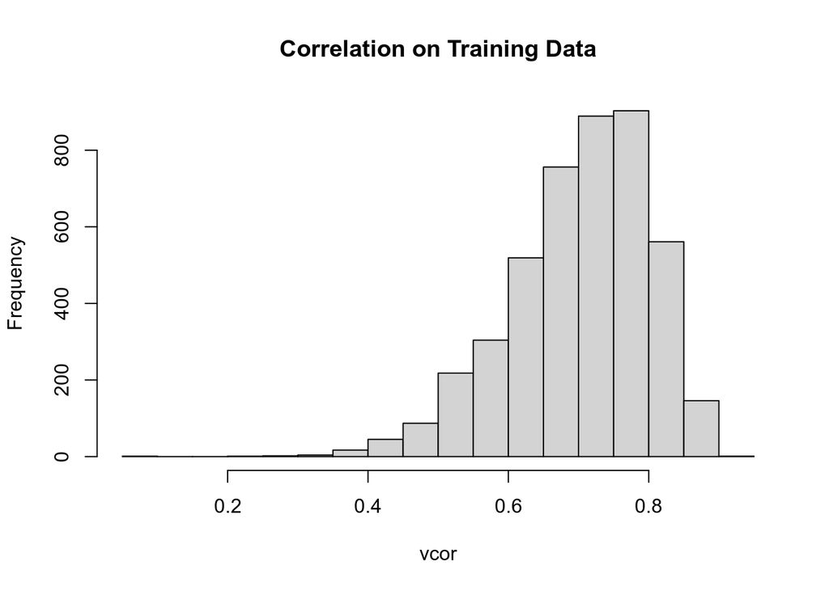

```r
vcor <- diag(cor(x.hat,xtrain))
hist(vcor, main = "Correlation on Training Data")
```

The histogram above shows that the correlation between the training data and the predictions from the first autoencoder are relatively high. Worth mentioning is that if the network is trained without the aforementioned callbacks, the correlation on the training set could be higher, as the network could continue to fit the parameters to the training data. As stated, this would probably have resulted in worse values for the initial test set that we set aside before the training started. We do the same check on the test set.

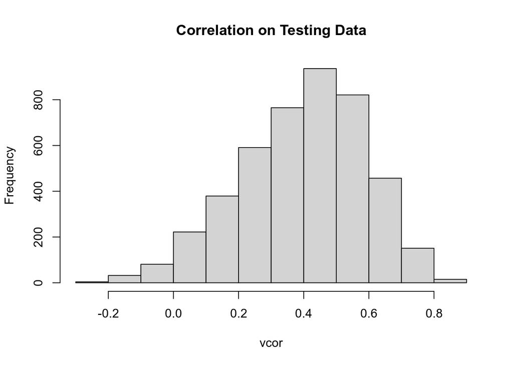

```r
x.hat <- predict(sae1,xtest)
vcor <- diag(cor(x.hat,xtest))
hist(vcor, main = "Correlation on Testing Data")
```

As expected, the correlation is lower on the test data, but there still is some correlation.

## 2.2 Second Layer (100 nodes)

```r
# Develop the encoder.
input_enc2 <- layer_input(shape = 1000)
output_enc2 <- input_enc2 %>%
  layer_dense(units=100,activation="relu")
encoder2 <- keras_model(input_enc2, output_enc2)
summary(encoder2)
```

```
#> Model: "model_49"
#> ______________________________________________________________________
#>  Layer (type)                  Output Shape                Param #
#> ======================================================================
#>  input_40 (InputLayer)         [(None, 1000)]              0
#>
#>  dense_44 (Dense)              (None, 100)                 100100
#>
#> ======================================================================
#> Total params: 100,100
#> Trainable params: 100,100
#> Non-trainable params: 0
#> ______________________________________________________________________
```

```r
# Develop the decoder.
input_dec2 <- layer_input(shape = 100)
output_dec2 <- input_dec2 %>%
  layer_dense(units = 1000, activation="linear")
decoder2 <- keras_model(input_dec2, output_dec2)
summary(decoder2)
```

```
#> Model: "model_50"
#> ______________________________________________________________________
#>  Layer (type)                  Output Shape                Param #
#> ======================================================================
#>  input_41 (InputLayer)         [(None, 100)]               0
#>
#>  dense_45 (Dense)              (None, 1000)                101000
#>
#> ======================================================================
#> Total params: 101,000
#> Trainable params: 101,000
#> Non-trainable params: 0
#> ______________________________________________________________________
```

```r
# Develop the second AE.
aen_input2 <- layer_input(shape = 1000)
aen_output2 <- aen_input2 %>%
  encoder2() %>%
  decoder2()
sae2 <- keras_model(aen_input2, aen_output2)
summary(sae2)
```

```
#> Model: "model_51"
#> ______________________________________________________________________
#>  Layer (type)                  Output Shape                Param #
#> ======================================================================
#>  input_42 (InputLayer)         [(None, 1000)]              0
#>
#>  model_49 (Functional)         (None, 100)                 100100
#>
#>  model_50 (Functional)         (None, 1000)                101000
#>
#> ======================================================================
#> Total params: 201,100
#> Trainable params: 201,100
#> Non-trainable params: 0
#> ______________________________________________________________________
```

We compile the model and fit it to the training data.

```r
sae2 %>% compile(
  optimizer = "rmsprop",
  loss = "mse"
)
```

```r
callbacks_parameters <- callback_early_stopping(
  monitor = "val_loss",
  patience = 8,
  verbose = 1,
  mode = "min",
  restore_best_weights = FALSE
)

sae2 %>% fit(
  x = encoded_expression1,
  y = encoded_expression1,
  epochs = 100,
  batch_size = 64,
  validation_split = 0.2,
  callbacks = callbacks_parameters
)
```

We make predictions on the training data, which in this case is the training data reduced in dimension from the first autoencoder. Similarly to earlier, we use callbacks for early stopping during training.

```r
encoded_expression2 <- encoder2 %>% predict(encoded_expression1)
decoded_expression2 <- decoder2 %>% predict(encoded_expression2)

# This method gives the same predictions as the two lines above.
# i.e. the values in decoded_expression2 above are the same as the values in x.hat below.
x.hat <- predict(sae2,encoded_expression1)
```

Some (weak) evidence of the quality of the coding obtained follows. We plot the correlation between the predictions from the autoencoder and the input data, which in this case is the encoded data from the first autoencoder (the latent variables/space).

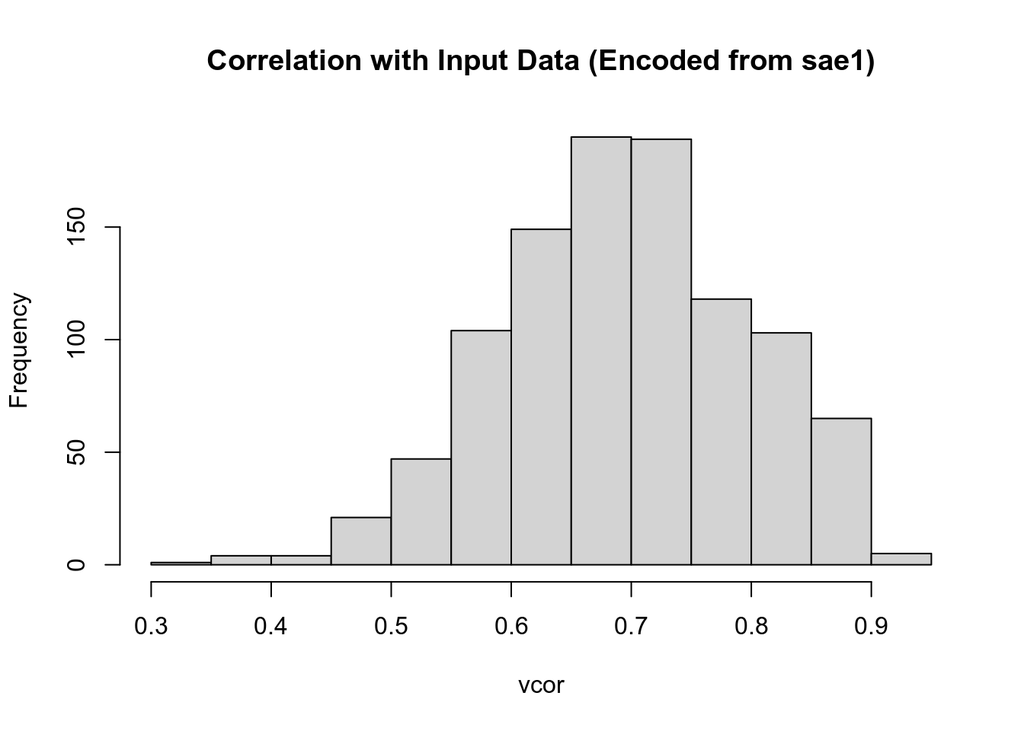

```r
vcor <- diag(cor(x.hat,encoded_expression1))
hist(vcor, main = "Correlation with Input Data (Encoded from sae1)")
```

The histogram above shows that there is correlation between the input and the predictions from the second autoencoder. Note that we do not have a test set in this case, since the dimension of the output data from sae2 is 1000, which is less than the amount of features in the test data. Since the histogram shows the correlation between the input and the predictions, the diagram is highly dependent on how many epochs the network is trained for (as is always the case in Deep Learning with neural networks).

## 2.3 Third Layer (50 nodes)

```r
# Develop the encoder.
input_enc3 <- layer_input(shape = 100)
output_enc3 <- input_enc3 %>%
  layer_dense(units=50,activation="relu")
encoder3 <- keras_model(input_enc3, output_enc3)
summary(encoder3)
```

```
#> Model: "model_52"
#> ______________________________________________________________________
#>  Layer (type)                  Output Shape                Param #
#> ======================================================================
#>  input_43 (InputLayer)         [(None, 100)]               0
#>
#>  dense_46 (Dense)              (None, 50)                  5050
#>
#> ======================================================================
#> Total params: 5,050
#> Trainable params: 5,050
#> Non-trainable params: 0
#> ______________________________________________________________________
```

```r
# Develop the decoder.
input_dec3 <- layer_input(shape = 50)
output_dec3 <- input_dec3 %>%
  layer_dense(units = 100, activation="linear")
decoder3 <- keras_model(input_dec3, output_dec3)
summary(decoder3)
```

```
#> Model: "model_53"
#> ______________________________________________________________________
#>  Layer (type)                  Output Shape                Param #
#> ======================================================================
#>  input_44 (InputLayer)         [(None, 50)]                0
#>
#>  dense_47 (Dense)              (None, 100)                 5100
#>
#> ======================================================================
#> Total params: 5,100
#> Trainable params: 5,100
#> Non-trainable params: 0
#> ______________________________________________________________________
```

```r
# Develop the third AE.
aen_input3 <- layer_input(shape = 100)
aen_output3 <- aen_input3 %>%
  encoder3() %>%
  decoder3()
sae3 <- keras_model(aen_input3, aen_output3)
summary(sae3)
```

```
#> Model: "model_54"
#> ______________________________________________________________________
#>  Layer (type)                  Output Shape                Param #
#> ======================================================================
#>  input_45 (InputLayer)         [(None, 100)]               0
#>
#>  model_52 (Functional)         (None, 50)                  5050
#>
#>  model_53 (Functional)         (None, 100)                 5100
#>
#> ======================================================================
#> Total params: 10,150
#> Trainable params: 10,150
#> Non-trainable params: 0
#> ______________________________________________________________________
```

We compile the model and fit it to the training data.

```r
sae3 %>% compile(
  optimizer = "rmsprop",
  loss = "mse"
)
```

```r
sae3 %>% fit(
  x = encoded_expression2,
  y = encoded_expression2,
  epochs = 150,
  batch_size = 64,
  validation_split = 0.2,
  callbacks = callbacks_parameters
)
```

We make predictions on the training data, which in this case is the training data reduced in dimension from the second autoencoder.

```r
encoded_expression3 <- encoder3 %>% predict(encoded_expression2)
decoded_expression3 <- decoder3 %>% predict(encoded_expression3)

# This method gives the same predictions as the two lines above.
# i.e. the values in decoded_expression3 above are the same as the values in x.hat below.
x.hat <- predict(sae3,encoded_expression2)
```

Some (weak) evidence of the quality of the coding obtained follows. We plot the correlation between the predictions from the autoencoder and the input data, which in this case is the encoded data from the second autoencoder (the latent variables/space).

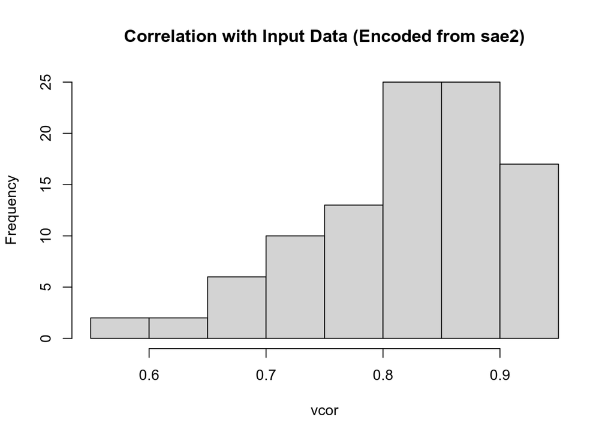

```r
vcor <- diag(cor(x.hat,encoded_expression2))
hist(vcor, main = "Correlation with Input Data (Encoded from sae2)")
```

## 2.4 Final Model (SAE)

The final stacked autoencoder (SAE) is constructed below; all the encoders previously trained are stacked together.

```r
sae_input <- layer_input(shape = percentage, name = "gene.mod")
sae_output <- sae_input %>%
  encoder1() %>%
  encoder2() %>%
  encoder3()

sae <- keras_model(sae_input, sae_output)
summary(sae)
```

```
#> Model: "model_55"
#> ______________________________________________________________________
#>  Layer (type)                  Output Shape                Param #
#> ======================================================================
#>  gene.mod (InputLayer)         [(None, 4454)]              0
#>
#>  model_46 (Functional)         (None, 1000)                4455000
#>
#>  model_49 (Functional)         (None, 100)                 100100
#>
#>  model_52 (Functional)         (None, 50)                  5050
#>
#> ======================================================================
#> Total params: 4,560,150
#> Trainable params: 4,560,150
#> Non-trainable params: 0
#> ______________________________________________________________________
```

```r
# Code below is used for loading model (and model checking) in separate file for tfruns().
# Predictions are used to check that weight-loading in separate file works as expected.
yhat <- predict(sae, xtest)
write.csv(yhat, file = "predictions.csv")
# Model weights are saved in order to reconstruct same model in separate file.
save_model_weights_hdf5(sae, "sae.hdf5")
```

# 3 SAE as Pre-Training Model for Prediction of Estrogen Receptor State

The SAE is used as a pre-training model for prediction of the BRCA estrogen receptor status. The DNN has 10 nodes in the first fully connected layer, followed by one output node. The weights are frozen for the first 3 functional layers, which means that only the weights from the third autoencoder to the first fully connected layer and from the first fully connected layer in the DNN to the output layer are to be fine-tuned to obtain the final classifier.

```r
sae_output2 <- sae_output %>%
  layer_dense(10,activation = "relu") %>% # Couple with fully connected layers (DNN).
  layer_dense(1,activation = "sigmoid")

sae <- keras_model(sae_input, sae_output2)
summary(sae)
```

```
#> Model: "model_56"
#> ______________________________________________________________________
#>  Layer (type)                  Output Shape                Param #
#> ======================================================================
#>  gene.mod (InputLayer)         [(None, 4454)]              0
#>
#>  model_46 (Functional)         (None, 1000)                4455000
#>
#>  model_49 (Functional)         (None, 100)                 100100
#>
#>  model_52 (Functional)         (None, 50)                  5050
#>
#>  dense_49 (Dense)              (None, 10)                  510
#>
#>  dense_48 (Dense)              (None, 1)                   11
#>
#> ======================================================================
#> Total params: 4,560,671
#> Trainable params: 4,560,671
#> Non-trainable params: 0
#> ______________________________________________________________________
```

```r
freeze_weights(sae,from=1,to=4) # Freeze the weights (pre-training using the SAE).
# Only the weights in the two coupled fully connected layers will be trained when freezed in this manner.
summary(sae)
```

```
#> Model: "model_56"
#> ______________________________________________________________________
#>  Layer (type)                  Output Shape                Param #
#> ======================================================================
#>  gene.mod (InputLayer)         [(None, 4454)]              0
#>
#>  model_46 (Functional)         (None, 1000)                4455000
#>
#>  model_49 (Functional)         (None, 100)                 100100
#>
#>  model_52 (Functional)         (None, 50)                  5050
#>
#>  dense_49 (Dense)              (None, 10)                  510
#>
#>  dense_48 (Dense)              (None, 1)                   11
#>
#> ======================================================================
#> Total params: 4,560,671
#> Trainable params: 521
#> Non-trainable params: 4,560,150
#> ______________________________________________________________________
```

We compile and fit the final classifier.

```r
sae %>% compile(
  optimizer = "rmsprop",
  loss = 'binary_crossentropy',
  metric = "acc"
)
```

```r
sae %>% fit(
  x=xtrain,
  y=ylabels,
  epochs = 120,
  batch_size=64,
  validation_split = 0.2,
  callbacks = callbacks_parameters
)
```

## 3.1 Performance Metrics

The model is evaluated on the test set below.

```r
sae %>%
  evaluate(xtest, ytestlabels)
```

```
#>      loss       acc
#> 0.3896434 0.8428571
```

Predictions on the test set are calculated. The classifier is built on the assumption that predictions of probability smaller than $0.5$ are negative receptor states, while probabilities larger than $0.5$ are positive receptor states. The confusion matrix of the predictions is shown below.

```r
yhat <- predict(sae,xtest)
yhatclass<-as.factor(ifelse(yhat<0.5,0,1))
confusionMatrix(yhatclass,as.factor(ytestlabels))
```

```
#> Confusion Matrix and Statistics
#>
#>           Reference
#> Prediction  0  1
#>          0  9  1
#>          1 10 50
#>
#>                Accuracy : 0.8429
#>                  95% CI : (0.7362, 0.9189)
#>     No Information Rate : 0.7286
#>     P-Value [Acc > NIR] : 0.01796
#>
#>                   Kappa : 0.5333
#>
#>  Mcnemar's Test P-Value : 0.01586
#>
#>             Sensitivity : 0.4737
#>             Specificity : 0.9804
#>          Pos Pred Value : 0.9000
#>          Neg Pred Value : 0.8333
#>              Prevalence : 0.2714
#>          Detection Rate : 0.1286
#>    Detection Prevalence : 0.1429
#>       Balanced Accuracy : 0.7270
#>
#>        'Positive' Class : 0
#>
```

The ROC curve is shown below.

```r
roc_sae_test1 <- roc(response = ytestlabels, predictor = as.numeric(yhat))
```

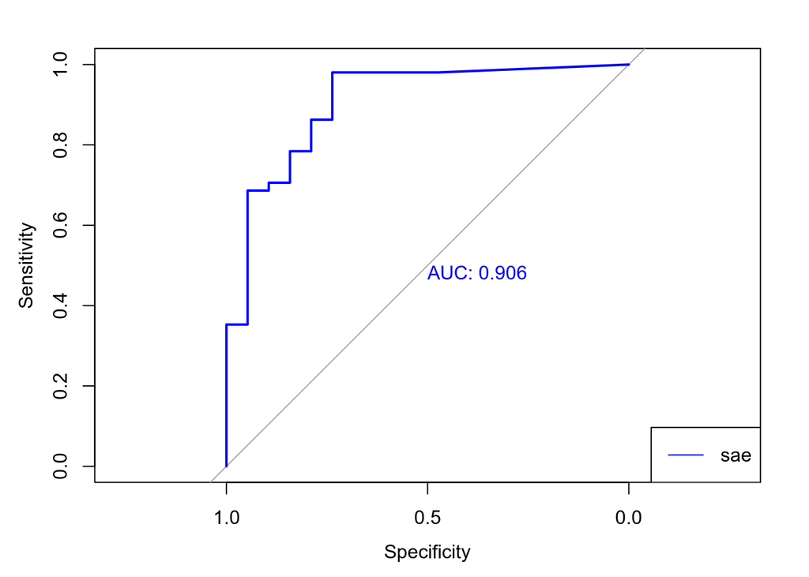

```r
plot(roc_sae_test1, col = "blue", print.auc=TRUE)
legend("bottomright", legend = c("sae"), lty = c(1), col = c("blue"))
```

As is seen above, the AUC is 0.91.

For an AUC curve, a score of 1 would signify a perfect predictor whilst a score of 0.5 would signify that the predictor has no ability to discriminate between classes. In this case, this would mean that the model would have no ability to predict a positive or negative BRCA receptor status. A score of 0.91 is therefore considered good, as it should be able to distinguish the various cases to a good extent. However, as always, there is still some room for improvement.

# 4 Use `tfruns` to Explore Configurations of First Fully Connected Layer

In this section, `tfruns` is used to explore what amount of nodes in the first layer of the DNN gives the best performance. We are asked to search among three different numbers; 5, 10 and 20. The code used with `tfruns` is given in separate R files. Notice that we perhaps could have sourced the code into this file, like will be done later with the concatenated model, but in this case we preferred the option of running the file separately while developing the models. The exploration leads to the conclusion that the configuration with 20 nodes gives the best results.

Thus, the final model is

```r
sae_output2 <- sae_output %>%
  layer_dense(20,activation = "relu") %>% # Couple with fully connected layers (DNN).
  layer_dense(1,activation = "sigmoid")

sae.final <- keras_model(sae_input, sae_output2)
summary(sae.final)
```

```
#> Model: "model_57"
#> ______________________________________________________________________
#>  Layer (type)                  Output Shape                Param #
#> ======================================================================
#>  gene.mod (InputLayer)         [(None, 4454)]              0
#>
#>  model_46 (Functional)         (None, 1000)                4455000
#>
#>  model_49 (Functional)         (None, 100)                 100100
#>
#>  model_52 (Functional)         (None, 50)                  5050
#>
#>  dense_51 (Dense)              (None, 20)                  1020
#>
#>  dense_50 (Dense)              (None, 1)                   21
#>
#> ======================================================================
#> Total params: 4,561,191
#> Trainable params: 1,041
#> Non-trainable params: 4,560,150
#> ______________________________________________________________________
```

```r
freeze_weights(sae.final,from=1,to=4) # Freeze the weights (pre-training using the SAE).
summary(sae.final)
```

```
#> Model: "model_57"
#> ______________________________________________________________________
#>  Layer (type)                  Output Shape                Param #
#> ======================================================================
#>  gene.mod (InputLayer)         [(None, 4454)]              0
#>
#>  model_46 (Functional)         (None, 1000)                4455000
#>
#>  model_49 (Functional)         (None, 100)                 100100
#>
#>  model_52 (Functional)         (None, 50)                  5050
#>
#>  dense_51 (Dense)              (None, 20)                  1020
#>
#>  dense_50 (Dense)              (None, 1)                   21
#>
#> ======================================================================
#> Total params: 4,561,191
#> Trainable params: 1,041
#> Non-trainable params: 4,560,150
#> ______________________________________________________________________
```

```r
sae.final %>% compile(
  optimizer = "rmsprop",
  loss = 'binary_crossentropy',
  metric = "acc"
)

sae.final %>% fit(
  x=xtrain,
  y=ylabels,
  epochs = 120,
  batch_size=64,
  validation_split = 0.2,
  callbacks = callbacks_parameters
)

sae.final %>%
  evaluate(xtest, ytestlabels)
```

```
#>      loss       acc
#> 0.2945561 0.9000000
```

```r
yhat <- predict(sae.final,xtest)
yhatclass<-as.factor(ifelse(yhat<0.5,0,1))
confusionMatrix(yhatclass,as.factor(ytestlabels))
```

```
#> Confusion Matrix and Statistics
#>
#>           Reference
#> Prediction  0  1
#>          0 15  3
#>          1  4 48
#>
#>                Accuracy : 0.9
#>                  95% CI : (0.8048, 0.9588)
#>     No Information Rate : 0.7286
#>     P-Value [Acc > NIR] : 0.0003901
#>
#>                   Kappa : 0.7429
#>
#>  Mcnemar's Test P-Value : 1.0000000
#>
#>             Sensitivity : 0.7895
#>             Specificity : 0.9412
#>          Pos Pred Value : 0.8333
#>          Neg Pred Value : 0.9231
#>              Prevalence : 0.2714
#>          Detection Rate : 0.2143
#>    Detection Prevalence : 0.2571
#>       Balanced Accuracy : 0.8653
#>
#>        'Positive' Class : 0
#>
```

```r
roc_sae_test2 <- roc(response = ytestlabels, predictor = as.numeric(yhat))
```

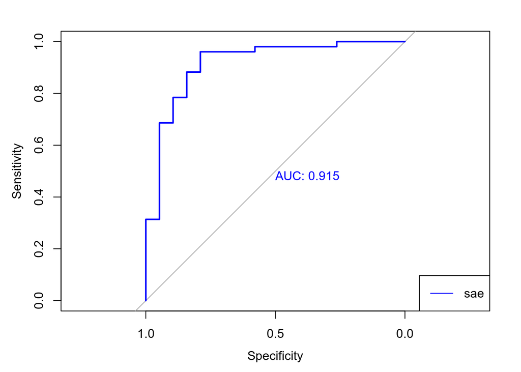

```r
plot(roc_sae_test2, col = "blue", print.auc=TRUE)
legend("bottomright", legend = c("sae"), lty = c(1), col = c("blue"))
```

From the ROC curve we see that the AUC-score is very similar to the earlier model. Each training of the model gives different results, which means that some runs yield a better model and others yield a worse model. On average, this model seems to be better, but notice that the differences seem to be minimal.

## 4.1 Complete Data

The **complete data** (gene expression and protein abundance) is split into train and test sets.

As explained in section 1, the same set of gene features is used in this data set, in order to secure that the input now consists of the same genes that the network was trained on in previous sections.

```r
chosen.data <- full.gene.prot.clin # Complete data set, as defined in part 1.
xclin <- clinical[,c(1,9)]
colnames(xclin) <- c("Sample", "BRCA")
xclin <- xclin[clinical$Sample %in% chosen.data, ]
xprot <- prot.ab[prot.ab$Sample %in% chosen.data,]
xgene <- gene.exp2[gene.exp2$Sample %in% chosen.data, ]

sel1 <- which(xclin$BRCA != "Positive")
sel2 <- which(xclin$BRCA != "Negative")
sel <- intersect(sel1,sel2) # Find values of BRCA that are neither negative nor positive.
# In this case these values are either "Indeterminate", "Not Performed" or NA.
xclin <- xclin[-sel,] # Remove the rows with non-valid data for BRCA.
xclin <- xclin[-which(is.na(xclin$BRCA)),] # Also remove rows with missing data for BRCA.

# Join the (cleaned) clinical data and the gene expression data on "Sample".
mgene <- merge(xclin, xgene, by.x = "Sample", by.y = "Sample")
mtot <- merge(mgene, xprot, by.x = "Sample", by.y = "Sample")
#mtot <- xclin %>% left_join(xgene) %>% left_join(xprot, by = "Sample") # This gives the same result.

mtot.patients <- mtot[,1] # Select patient sample codes that have all data available.

set.seed(params$seed)
training.fraction <- 0.70 # 70 % of data will be used for training.
training <- sample(1:nrow(mtot),nrow(mtot)*training.fraction)

xprot2 <- xprot %>% dplyr::filter(Sample %in% mtot.patients)
xprot.train <- xprot2[training,-1]
xprot.test <- xprot2[-training,-1]

xgene2 <- xgene %>% dplyr::filter(Sample %in% mtot.patients)

# Pick out the same features as in the first model (as noted in section 1.1.1).
xgene2 <- xgene2[, c(1,sorted)] # Select the 25% largest variance variables using the indices found in section 1.1.1.
# We also select the patient sample id, following the same pattern as above (thus c(1,sorted) above.
xgene.train <- xgene2[training,-1]
xgene.test <- xgene2[-training,-1]

# Scaling for better numerical stability.
# This is a standard "subtract mean and divide by standard deviation" scaling.
xprot.test <- scale(data.matrix(xprot.test))
xprot.train <- scale(data.matrix(xprot.train))
xgene.test <- scale(data.matrix(xgene.test))
xgene.train <- scale(data.matrix(xgene.train))

# ADDITIONAL CHECK: Make sure that the patients of the labels and feature data are the same.
all.equal(tibble(mtot[,1]), xgene2[,1], check.attributes = F)
```

```
#> [1] TRUE
```

```r
all.equal(tibble(mtot[,1]), xprot2[,1], check.attributes = F)
```

```
#> [1] TRUE
```

```r
ytrain <- mtot[training,2] # Pick out training labels.
ytest <- mtot[-training,2] # Pick out testing labels.

# Change labels to numerical values in train and test set.
ylabels.comp <- c()
ylabels.comp[ytrain=="Positive"] <- 1
ylabels.comp[ytrain=="Negative"] <- 0

ytestlabels.comp <- c()
ytestlabels.comp[ytest=="Positive"] <- 1
ytestlabels.comp[ytest=="Negative"] <- 0

# Lables are change to categorical, in order to facilitate two output nodes in concatenated model.
ytrain.bin <- to_categorical(as.array(ylabels.comp), 2)
ytest.bin <- to_categorical(as.array(ytestlabels.comp), 2)
```

## 4.2 Importing the SAE from the class example.

The SAE for the abundance of proteins (from class examples) is added in the code block below. Then, this model is concatenated with the former model, that was trained on the gene expression data.

```r
# Model given by teaching staff. A lot of code from the original file is removed and variables are renamed.
source("aes_practice_3.R") # source: Parses the code and evaluates it in this environment.
```

```
#> Model: "model_58"
#> ______________________________________________________________________
#>  Layer (type)                  Output Shape                Param #
#> ======================================================================
#>  input_46 (InputLayer)         [(None, 142)]               0
#>
#>  dense_52 (Dense)              (None, 50)                  7150
#>
#> ======================================================================
#> Total params: 7,150
#> Trainable params: 7,150
#> Non-trainable params: 0
#> ______________________________________________________________________
#> Model: "model_59"
#> ______________________________________________________________________
#>  Layer (type)                  Output Shape                Param #
#> ======================================================================
#>  input_47 (InputLayer)         [(None, 50)]                0
#>
#>  dense_53 (Dense)              (None, 142)                 7242
#>
#> ======================================================================
#> Total params: 7,242
#> Trainable params: 7,242
#> Non-trainable params: 0
#> ______________________________________________________________________
#> Model: "model_60"
#> ______________________________________________________________________
#>  Layer (type)                  Output Shape                Param #
#> ======================================================================
#>  input_48 (InputLayer)         [(None, 142)]               0
#>
#>  model_58 (Functional)         (None, 50)                  7150
#>
#>  model_59 (Functional)         (None, 142)                 7242
#>
#> ======================================================================
#> Total params: 14,392
#> Trainable params: 14,392
#> Non-trainable params: 0
```

[output cut: 110 more lines]

```
#>  model_58 (Functional)         (None, 50)                  7150
#>
#>  model_61 (Functional)         (None, 20)                  1020
#>
#>  model_64 (Functional)         (None, 10)                  210
#>
#>  dense_59 (Dense)              (None, 5)                   55
#>
#>  dense_58 (Dense)              (None, 1)                   6
#>
#> ======================================================================
#> Total params: 8,441
#> Trainable params: 61
#> Non-trainable params: 8,380
#> ______________________________________________________________________
```

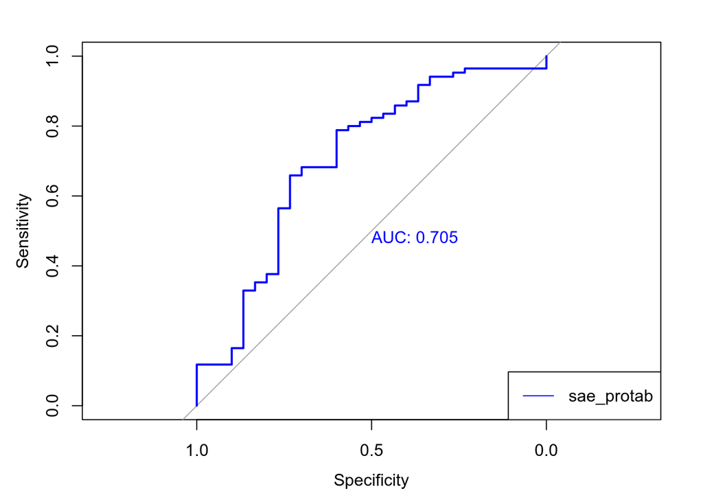

# 5 Concatenated Model

In this section we concatenate the two SAEs to fit, on the trainset, a DNN that integrates both data sources to predict estrogen receptor status. The DNN has a dense layer, with 20 nodes, which where the best amount of nodes found with `tfruns` earlier, in addition to the output layer.

The two models are concatenated below.

```r
sae_output3 <- sae_input %>%
  encoder1() %>%
  encoder2() %>%
  encoder3() %>%
  layer_dense(units=20, activation = "relu")

sae_protab_output <- sae_protab_input %>%
  prot_encoder1() %>%
  prot_encoder2() %>%
  prot_encoder3() %>%
  layer_dense(units=20, activation = "relu")


concatenated <- layer_concatenate(list(sae_output3,sae_protab_output))

final_model_output <- concatenated %>%
  layer_dense(units=2,activation="softmax")

model <- keras_model(list(sae_input,sae_protab_input), final_model_output)
summary(model)
```

```
#> Model: "model_68"
#> ______________________________________________________________________
#>  Layer (type)          Output Shape   Param   Connected to
#>                                       #
#> ======================================================================
#>  gene.mod (InputLayer)  [(None, 4454)  0      []
#>                        ]
#>
#>  prot.mod (InputLayer)  [(None, 142)]  0      []
#>
#>  model_46 (Functional)  (None, 1000)  445500  ['gene.mod[0][0]']
#>                                       0
#>
#>  model_58 (Functional)  (None, 50)    7150    ['prot.mod[0][0]']
#>
#>  model_49 (Functional)  (None, 100)   100100  ['model_46[2][0]']
#>
#>  model_61 (Functional)  (None, 20)    1020    ['model_58[2][0]']
#>
#>  model_52 (Functional)  (None, 50)    5050    ['model_49[2][0]']
#>
#>  model_64 (Functional)  (None, 10)    210     ['model_61[2][0]']
#>
#>  dense_60 (Dense)      (None, 20)     1020    ['model_52[2][0]']
#>
#>  dense_61 (Dense)      (None, 20)     220     ['model_64[2][0]']
#>
#>  concatenate_2 (Concat  (None, 40)    0       ['dense_60[0][0]',
#>  enate)                                        'dense_61[0][0]']
#>
#>  dense_62 (Dense)      (None, 2)      82      ['concatenate_2[0][0]']
#>
#> ======================================================================
#> Total params: 4,569,852
#> Trainable params: 1,322
#> Non-trainable params: 4,568,530
#> ______________________________________________________________________
```

As can be seen from the parameters of the model above, only the weights for the dense layers will be fine-tuned during training of the concatenated model, in accordance with the procedure used earlier in the task.

```r
model %>% compile(
  optimizer = "rmsprop",
  loss = "categorical_crossentropy",
  metrics = "acc"
)

model %>% fit(
  x=list(as.matrix(xgene.train),as.matrix(xprot.train)),
  y=ytrain.bin,
  epochs = 90,
  batch_size = 64,
  validation_split = 0.2,
  callbacks = callbacks_parameters
)
```

## 5.1 Performance Metrics

The model is evaluated on the test set below.

```r
model %>%
  evaluate(x=list(as.matrix(xgene.test),as.matrix(xprot.test)),
  y=ytest.bin)
```

```
#>      loss       acc
#> 0.5101074 0.8148148
```

Predictions on the test set are calculated. The classifier is built on the assumption that predictions of probability smaller than $0.5$ are negative receptor states, while probabilities larger than $0.5$ are positive receptor states. The confusion matrix of the predictions is shown below.

```r
yhat <- as.array(model %>% predict(list(as.matrix(xgene.test),as.matrix(xprot.test))) %>% k_argmax())
yhatclass <- as.factor(yhat)
confusionMatrix(yhatclass,as.factor(ytestlabels.comp))
```

```
#> Confusion Matrix and Statistics
#>
#>           Reference
#> Prediction  0  1
#>          0 12  2
#>          1  8 32
#>
#>                Accuracy : 0.8148
#>                  95% CI : (0.6857, 0.9075)
#>     No Information Rate : 0.6296
#>     P-Value [Acc > NIR] : 0.002604
#>
#>                   Kappa : 0.5768
#>
#>  Mcnemar's Test P-Value : 0.113846
#>
#>             Sensitivity : 0.6000
#>             Specificity : 0.9412
#>          Pos Pred Value : 0.8571
#>          Neg Pred Value : 0.8000
#>              Prevalence : 0.3704
#>          Detection Rate : 0.2222
#>    Detection Prevalence : 0.2593
#>       Balanced Accuracy : 0.7706
#>
#>        'Positive' Class : 0
#>
```

The ROC curve is shown below.

```r
roc_sae_test.concat <- roc(response = ytestlabels.comp, predictor = as.numeric(yhat))
```

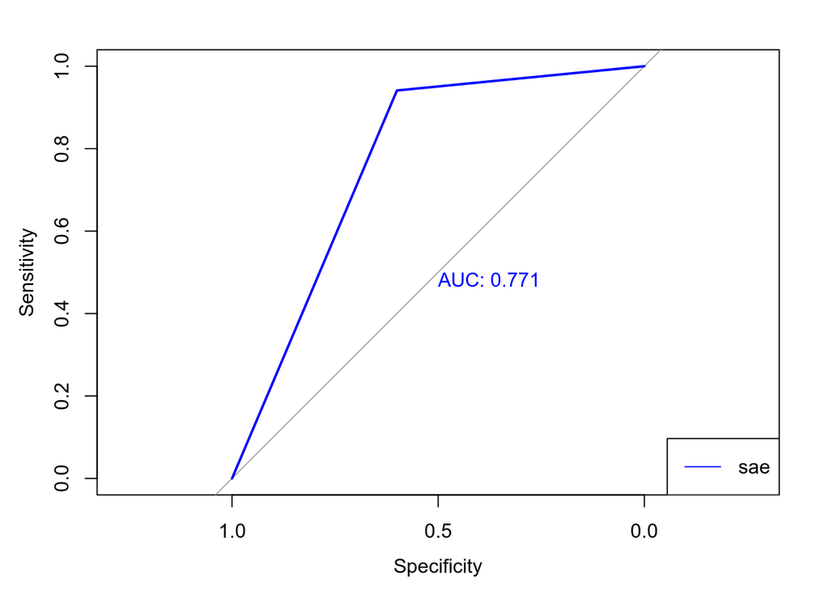

```r
plot(roc_sae_test.concat, col = "blue", print.auc=TRUE)
legend("bottomright", legend = c("sae"), lty = c(1), col = c("blue"))
```

# 6 Discussion

## 6.1 Comparing Performance Metrics of the Two Models

As one can see in the latter graph, the ROC curve of the concatenated model is looking linear at several points. In the first ROC curve, it is more curved. This is, of course, due to the AUC being closer to 1, however it is also due to a large instance of our cases on our concatenated model having the same value. This further substantiates the observation or conclusion that the second model performs worse than the first model. In short, the negligence of the importance of the different data given has led to a worse performance of the concatenated model. By concatenating, we have united an ok-performing model with a well-performing model and overfed it information, leading to a bad AUC score.

The first model and the concatenated model are based on two different activation functions; the first model incorporates one output node with the sigmoid activation function and `binary_crossentropty` loss, while the concatenated model incorporates two output nodes with the softmax activation function and `categorical_crossentropy` loss. The sigmoid function is often used for binary classifier problems - such as the one we are facing. The softmax function, as used in the last model, is based on a probability distribution of each element in the data given. This also means that the probabilities here are based on the input number given - a larger input number gives a larger probability, and they are all added to give an absolute score. If we connect this to the nature of the `keras` function `concatenate_layer()`, we can see that some values may have been given unfairly large - or unfairly small - bias when calculating the probability. We tried avoiding this through the pre-processing of data (for example by choosing the 25% of columns with highest variability), as well as the scaling of our variables depending on columns, however this fault is unavoidable. Thereby, the usage of the softmax function for two different datasets may lead to a worse performance of the model as it doesn’t “discriminate” according to significance of variables.

## 6.2 General Discussion

There seems to be some different angles to address the first step of processing the data sets. The removal of the patients samples with missing values in the gene expression data set seems to be an important step to secure that all used patients has complete data to pass as input to the network. The question then arise if we only should include the patients samples that both exist in the gene expression data set and the protein abundance data set when implementing the stacked autoencoder, to then be able to use the same set for the concatenate version in the later stage. Since the first part asked specificly to implement a SAE with the gene expression data we choose the alternative that was to include all complete patients in the gene expression data set, with no consideration of they existed in the protein abundance data set. Our motivation was that this should work as least as good as the alternative for the SAE, since this method gave more patients left in the actual used training set.

One thing to remember when choosing the above described way is that we should make sure that the same genes that were selected for the training of the first SAE are also the selected in the preparation of the joint data set for the concatenate SAE. Otherwise we risk training the first SAE on one set of genes from each patient and then using it on a potential other set of genes.

In the training of the SAE one difficulty is to avoid both underfitting and overfitting on the training data. With the aim to run each training for a suitable amount of epochs each training were monitored so that it could not keep training the network if the performance on the validation set did not increase during a fixed number of epochs. The intention is that this will lead to a network with better performance on the test set. This process was done using “callbacks”. Some parameters for the callbacks were specified: the progress to monitor was set to be the validation loss (the “val-loss”) and the mode was set to minimize this. In the very first training the patience was set to 12, that is the number of epochs the the training could continue without any improvement in the “val-loss”. All other training sessions were using callbacks with patience 8. The reason for this were that the first training did often encounter a quite low value in “val-loss” within the very first epochs, followed by a couple of higher values in “val-loss”. With a low value on patience, this could lead to that the network only trained for a couple of epochs. The extra added patience-epochs then gives the first training better chances to either find a better “val-loss”-value and reset the patience-counter or to at least continue training before the patience is reached and the training is stopped. The last fact is working due to another parameter choice to not revert to weights corresponding to the earlier encountered best “val-loss”. Whether the patience parameter should be reduced or the weight should be reverted to the stage of the best run or not is not so certain. After the first training, the other sessions generally last for much longer epochs, and are therefor not as sensible to a few epochs, but the callbacks still allows the training to last for long without the overfitting risk (if implemented correctly).

Notice that we could have used other techniques to improve generalization, like dropout. Moreover, the optimizer is chosen somewhat arbitrarily among the many in existence, which means that the optimizer used throughout the task might not be optimal for this problem.

The optimal value chosen using `tfruns` is not the absolute best value statistically decided, as each training and testing run yields different results. We chose the best model based on a few runs, but a better way might be to run the model many more times and choose the configuration that comes out on top the most times. The results do not seem to depend highly on this configuration however.

Lastly, we note that in order to avoid problems with differing output files and retraining every time the `Rmd` is run (since pseudo-random numbers and iterative optimization techniques are used during training), we should have trained the models separately and simply saved the trained models (or the weights), using the relevant `keras` API. These models or weights could then have been loaded into this file, as is done in the separate `task1_explore_conf_DNN.R` file for `tfruns`. This would have made the discussions consistent from render to render and would have made our lives easier. Note to self for next time.